# Practical Machine Learning Course Project

Jamie Davidson

27/10/2020

## Loading and Tidying the Data

First the packages required for the project are loaded and the random seed is set for reproducibility.

```r
library(dplyr)
```

```r
library(tidyr)
library(doParallel)
library(caret)
library(ggplot2)
library(mlbench)

set.seed(133456)
```

Next we load the entirety of the dataset into R.

```r
alldata<-read.csv("pml-training.csv")
```

The next step is tidying the data and preparing to apply the preproccessing and machine learning algorithms to it. The “user_name” variable, containing the name of the deadlifter is a character variable, which is incompatible with a number of machine learning algorithms. To get around this while preserving the information of who is lifting, a set of dummy variables is used. The “classe” variable which describes in what way the deadlift was performed is also converted to a factor.

```r
user_dmy<-dummyVars(~as.factor(user_name), data=alldata)
user_dmyDF<-predict(user_dmy, alldata)
alldata<-select(alldata, -user_name)
alldata<-merge(user_dmyDF, alldata, by=0, all=TRUE)
alldata$classe<-as.factor(alldata$classe)
```

Next, a large number of columns in the dataset contain a very large number of “NA” or empty values only being used to store summary statistics. These are excluded from the analysis as the data set on which predictions need to be made does not include them.

```r
alldata<-alldata[,!colSums(is.na(alldata))>0]
alldata<-alldata[,!colSums(alldata=="")>0]
```

Finally, columns that will not be useful in predicting the method of lifting outside this specific dataset are removed. These columns and the logic for removing them are as follows:

- Row.names - This is an artifact of the merge operation that added dummy variables to the dataset.
- X - the index of the dataset will have no predictive power when applied to new pieces of information.
- new_window - new window is a boolean variable that denotes the start and end of a new session and indicates the row contains summary statistics. As none of the entries in the set for which predictions need to be made include summary statistics this column is not required.
- Time variables (raw_timestamp_part_1, raw_timestamp_part_2, cvtd_timestamp, num_window) - the time of day that the training data was captured has no predictive power on other datasets as is shown in the plot below.

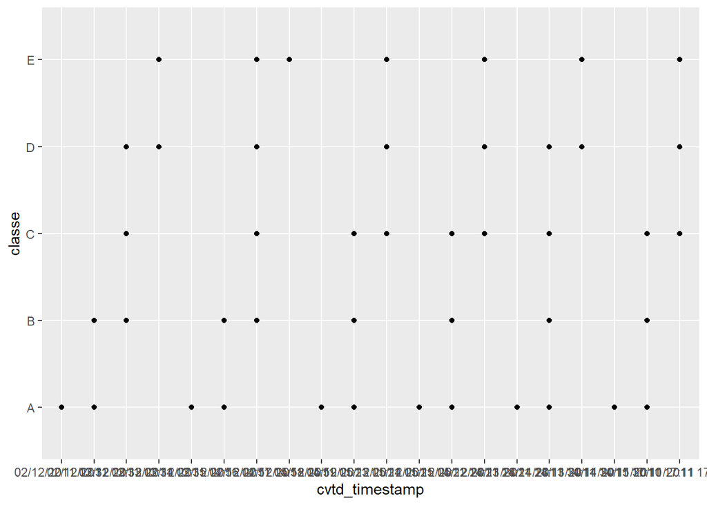

```r
plot<-ggplot(data=alldata, aes(y=classe, x=cvtd_timestamp))
plot+geom_point()
```

```r
alldata<-select(alldata, c(-Row.names, -X,
                -new_window, -raw_timestamp_part_1,
                -raw_timestamp_part_2, -cvtd_timestamp,
                -num_window))
```

## Preprocessing

```r
inTest<-createDataPartition(alldata$classe, p=0.25, list=FALSE)
testing<-alldata[inTest,]
training<-alldata[-inTest,]
inVal<-createDataPartition(training$classe, p=0.2, list=FALSE)
val<-training[inVal,]
training<-training[-inVal,]
dim(training)
```

```
## [1] 11770    59
```

```r
BoxCoxProc<-preProcess(x=training[-59], method=c("BoxCox", "center", "scale"))
PCAComp<-prcomp(predict(BoxCoxProc, training[-59]))
summary(PCAComp)
```

```
## Importance of components:
##                           PC1    PC2     PC3     PC4     PC5     PC6    PC7
## Standard deviation     3.0926 3.0370 2.32084 2.11260 2.05033 1.92389 1.5250
## Proportion of Variance 0.1649 0.1590 0.09287 0.07695 0.07248 0.06382 0.0401
## Cumulative Proportion  0.1649 0.3239 0.41680 0.49374 0.56622 0.63004 0.6701
##                            PC8     PC9    PC10    PC11    PC12    PC13    PC14
## Standard deviation     1.51470 1.35740 1.31482 1.23181 1.17805 1.00537 0.99942
## Proportion of Variance 0.03956 0.03177 0.02981 0.02616 0.02393 0.01743 0.01722
## Cumulative Proportion  0.70970 0.74147 0.77127 0.79743 0.82136 0.83879 0.85601
##                           PC15    PC16    PC17    PC18    PC19    PC20    PC21
## Standard deviation     0.93544 0.90084 0.84634 0.75128 0.72113 0.70721 0.67908
## Proportion of Variance 0.01509 0.01399 0.01235 0.00973 0.00897 0.00862 0.00795
## Cumulative Proportion  0.87110 0.88509 0.89744 0.90717 0.91614 0.92476 0.93271
##                           PC22    PC23    PC24    PC25    PC26    PC27    PC28
## Standard deviation     0.63488 0.61234 0.59213 0.55870 0.55213 0.50794 0.50126
## Proportion of Variance 0.00695 0.00646 0.00605 0.00538 0.00526 0.00445 0.00433
## Cumulative Proportion  0.93966 0.94612 0.95217 0.95755 0.96281 0.96725 0.97159
##                           PC29    PC30    PC31   PC32    PC33    PC34   PC35
## Standard deviation     0.45587 0.40524 0.39053 0.3734 0.35786 0.34346 0.3145
## Proportion of Variance 0.00358 0.00283 0.00263 0.0024 0.00221 0.00203 0.0017
## Cumulative Proportion  0.97517 0.97800 0.98063 0.9830 0.98524 0.98728 0.9890
##                           PC36    PC37    PC38    PC39    PC40    PC41    PC42
## Standard deviation     0.28752 0.25346 0.24264 0.23599 0.22548 0.19830 0.19447
## Proportion of Variance 0.00143 0.00111 0.00102 0.00096 0.00088 0.00068 0.00065
## Cumulative Proportion  0.99041 0.99151 0.99253 0.99349 0.99437 0.99504 0.99570
##                          PC43    PC44    PC45    PC46    PC47    PC48    PC49
## Standard deviation     0.1863 0.18157 0.17282 0.16290 0.15372 0.14856 0.14211
## Proportion of Variance 0.0006 0.00057 0.00051 0.00046 0.00041 0.00038 0.00035
## Cumulative Proportion  0.9963 0.99686 0.99738 0.99784 0.99824 0.99862 0.99897
##                           PC50    PC51    PC52    PC53    PC54    PC55    PC56
## Standard deviation     0.11985 0.11551 0.10299 0.08672 0.08122 0.06248 0.04624
## Proportion of Variance 0.00025 0.00023 0.00018 0.00013 0.00011 0.00007 0.00004
## Cumulative Proportion  0.99922 0.99945 0.99963 0.99976 0.99988 0.99994 0.99998
##                           PC57      PC58
## Standard deviation     0.03363 8.828e-14
## Proportion of Variance 0.00002 0.000e+00
## Cumulative Proportion  1.00000 1.000e+00
```

Generating the preprocessed training, test and validation set.

```r
preprocessor<-preProcess(x=training[-59], method=c("BoxCox", "center", "scale","pca"), thresh=0.9)
trainPC<-predict(preprocessor, training[-59])
trainPC$classe<-training$classe
valPC<-predict(preprocessor, val[-59])
valPC$classe<-val$classe
testPC<-predict(preprocessor, testing[-59])
testPC$classe<-testing$classe
```

## Model Training

First, a selection of common classification algorithms are trained to give an idea of which algorithms will be most useful. The chosen models are: * Random Forest * Boosted Logistic Regression * Linear Discriminant Analysis * A Support vector Machine * The C5.0 decision tree model

Parallel computing is used to accelerate the training process.

```r
no_cores <- detectCores()-2
cl<-makeCluster(no_cores)
registerDoParallel(cl)

modelFitRF<-train(classe~.,method="rf",data=trainPC)
modelFitLB<-train(classe~.,method="LogitBoost",data=trainPC)
modelFitLDA<-train(classe~.,method="lda",data=trainPC)
modelFitSVM<-train(classe~.,method="svmRadial",data=trainPC)
modelFitC5<-train(classe~.,method="C5.0",data=trainPC)
stopCluster(cl)
```

The accuracy of the models on the training set are then as follows:

```r
confusionMatrix(modelFitRF)
```

```
## Bootstrapped (25 reps) Confusion Matrix
##
## (entries are percentual average cell counts across resamples)
##
##           Reference
## Prediction    A    B    C    D    E
##          A 27.8  0.6  0.2  0.1  0.0
##          B  0.3 17.8  0.4  0.1  0.3
##          C  0.2  0.7 16.5  0.9  0.2
##          D  0.1  0.1  0.4 15.1  0.2
##          E  0.0  0.1  0.1  0.1 17.8
##
##  Accuracy (average) : 0.9499
```

```r
confusionMatrix(modelFitLB)
```

```
## Bootstrapped (25 reps) Confusion Matrix
##
## (entries are percentual average cell counts across resamples)
##
##           Reference
## Prediction    A    B    C    D    E
##          A 25.3  3.7  4.9  1.9  1.9
##          B  1.7  8.1  1.3  1.4  2.4
##          C  2.2  2.4  7.2  1.4  1.4
##          D  2.4  1.9  1.0  8.0  2.0
##          E  0.6  1.6  0.7  2.1 12.4
##
##  Accuracy (average) : 0.6106
```

```r
confusionMatrix(modelFitLDA)
```

```
## Bootstrapped (25 reps) Confusion Matrix
##
## (entries are percentual average cell counts across resamples)
##
##           Reference
## Prediction    A    B    C    D    E
##          A 18.9  4.0  6.5  2.0  2.6
##          B  2.3  8.7  1.8  3.4  3.2
##          C  2.8  2.9  7.0  1.9  1.9
##          D  4.0  3.1  1.4  7.6  2.0
##          E  0.5  0.6  0.7  1.6  8.7
##
##  Accuracy (average) : 0.5086
```

```r
confusionMatrix(modelFitSVM)
```

```
## Bootstrapped (25 reps) Confusion Matrix
##
## (entries are percentual average cell counts across resamples)
##
##           Reference
## Prediction    A    B    C    D    E
##          A 26.8  2.2  1.3  0.7  0.3
##          B  0.5 15.1  1.3  0.3  0.7
##          C  0.6  1.6 14.1  1.7  1.0
##          D  0.4  0.2  0.6 13.7  0.8
##          E  0.1  0.1  0.1  0.1 15.6
##
##  Accuracy (average) : 0.853
```

```r
confusionMatrix(modelFitC5)
```

```
## Bootstrapped (25 reps) Confusion Matrix
##
## (entries are percentual average cell counts across resamples)
##
##           Reference
## Prediction    A    B    C    D    E
##          A 27.6  0.8  0.4  0.3  0.1
##          B  0.3 17.7  0.7  0.1  0.4
##          C  0.2  0.5 15.6  0.8  0.2
##          D  0.3  0.2  0.7 15.1  0.2
##          E  0.1  0.2  0.2  0.1 17.3
##
##  Accuracy (average) : 0.9332
```

The two best performing algorithms are the random forest and C5.0 decision tree models, both boasting an accuracy of over 90%. Examining both models in more detail:

### C5.0 Model

```r
print(modelFitC5)
```

```
## C5.0
##
## 11770 samples
##    18 predictor
##     5 classes: 'A', 'B', 'C', 'D', 'E'
##
## No pre-processing
## Resampling: Bootstrapped (25 reps)
## Summary of sample sizes: 11770, 11770, 11770, 11770, 11770, 11770, ...
## Resampling results across tuning parameters:
##
##   model  winnow  trials  Accuracy   Kappa
##   rules  FALSE    1      0.8097635  0.7591739
##   rules  FALSE   10      0.9182950  0.8965363
##   rules  FALSE   20      0.9332138  0.9154254
##   rules   TRUE    1      0.8097635  0.7591739
##   rules   TRUE   10      0.9182950  0.8965363
##   rules   TRUE   20      0.9332138  0.9154254
##   tree   FALSE    1      0.8106238  0.7603552
##   tree   FALSE   10      0.9153476  0.8928477
##   tree   FALSE   20      0.9299194  0.9112922
##   tree    TRUE    1      0.8106238  0.7603552
##   tree    TRUE   10      0.9153476  0.8928477
##   tree    TRUE   20      0.9299194  0.9112922
##
## Accuracy was used to select the optimal model using the largest value.
## The final values used for the model were trials = 20, model = rules and
##  winnow = TRUE.
```

The automatic tuning of the hyperparameters shows that the rules based model achieves higher accuracy, as does increased number of trials. The effect of winnowing appears minimal. The effect of increasing the number of trails and winoowing can be investigated using a tuning grid:

```r
no_cores <- detectCores()-2
cl<-makeCluster(no_cores)
registerDoParallel(cl)
fitControl<-trainControl(method="repeatedcv",number=10,repeats=10,returnResamp = "all")
grid <- expand.grid(.winnow = TRUE, .trials=c(15,20,25), .model="rules" )
modelFitC5_tuning<- train(classe~., data=trainPC,tuneGrid=grid,trControl=fitControl,method="C5.0",verbose=FALSE)
stopCluster(cl)
```

Visualising the tuning results:

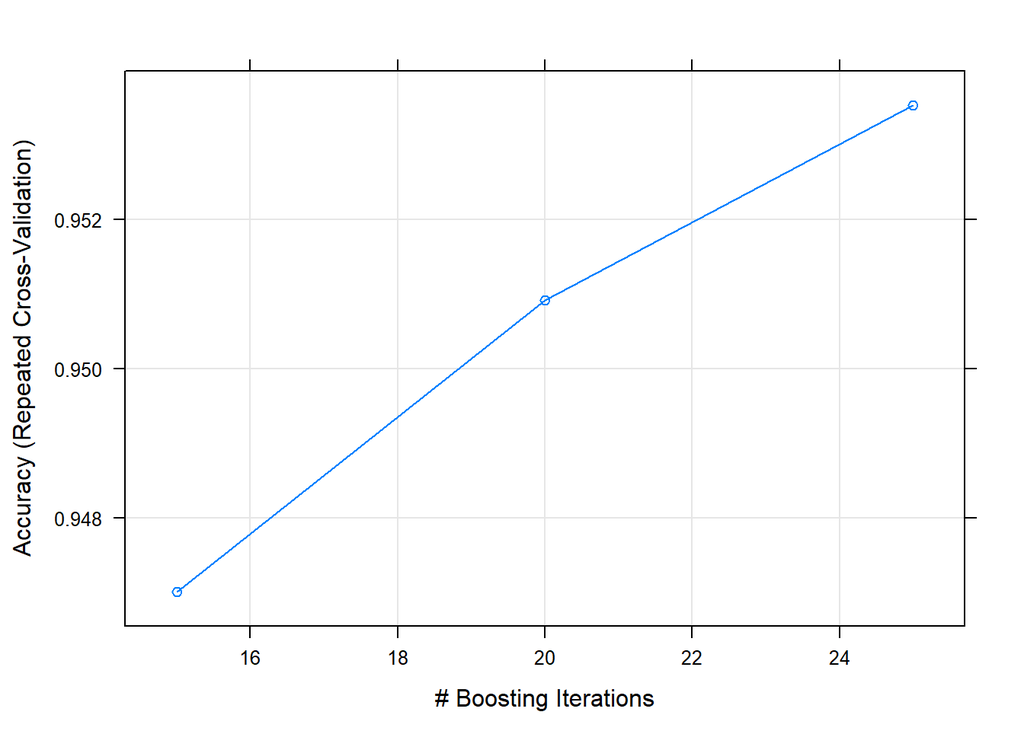

```r
plot(modelFitC5_tuning)
```

The plot shows that increasing the number of boosting iterations increases the accuracy of the model, but not very significantly, with an increase of 15 to 25 giving only a 0.5% increase in accuracy. 25 boosting iterations will be used in the final version of the C5.0 algorithm for this project.

### Random Forest Model

Printing the hyperparameter tuning of the random forest model:

```r
print(modelFitRF)
```

```
## Random Forest
##
## 11770 samples
##    18 predictor
##     5 classes: 'A', 'B', 'C', 'D', 'E'
##
## No pre-processing
## Resampling: Bootstrapped (25 reps)
## Summary of sample sizes: 11770, 11770, 11770, 11770, 11770, 11770, ...
## Resampling results across tuning parameters:
##
##   mtry  Accuracy   Kappa
##    2    0.9499148  0.9366228
##   10    0.9435380  0.9285568
##   18    0.9328445  0.9150349
##
## Accuracy was used to select the optimal model using the largest value.
## The final value used for the model was mtry = 2.
```

The automatic tuning indicates that varying the “mtry” variable may have little effect on the accuracy, we can examine this in more detail however, as well as examining the effect of the number of trees used in the model.

```r
no_cores <- detectCores()-2
cl<-makeCluster(no_cores)
registerDoParallel(cl)
fitControl<-trainControl(method="repeatedcv",number=10,repeats=10,returnResamp = "all")
grid <- expand.grid(.mtry=c(2,3,4,5))
modelFitRF_tuning500<- train(classe~., data=trainPC,tuneGrid=grid,trControl=fitControl,method="rf",verbose=FALSE,ntree=500)
modelFitRF_tuning1000<- train(classe~., data=trainPC,tuneGrid=grid,trControl=fitControl,method="rf",verbose=FALSE,ntree=1000)
stopCluster(cl)
```

Visualising the results:

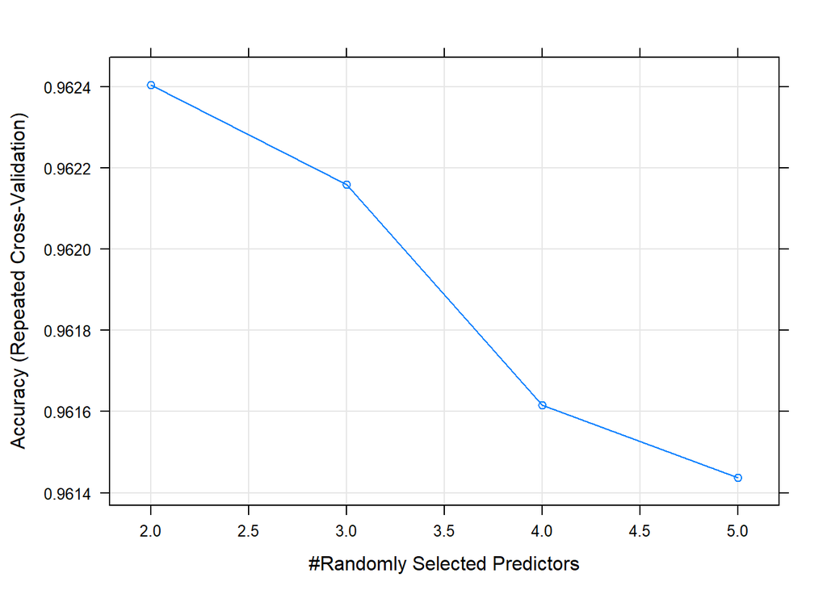

```r
par(mfrow=c(1,2))
plot(modelFitRF_tuning500)
```

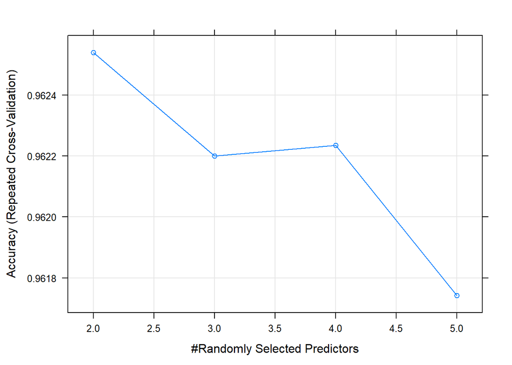

```r
plot(modelFitRF_tuning1000)
```

The plots shows that the mtry variable is already well optimised by the built in methods with a value of 2. Using 1000 trees gives slightly higher accuracy than 500 tree model.

### Final Model Selection

Comparing the two models on the validation set:

```r
RF_predictions<-predict(modelFitRF_tuning1000, newdata = valPC[-19])
C5_predictions<-predict(modelFitC5_tuning, newdata = valPC[-19])
confusionMatrix(C5_predictions, valPC$classe)$overall["Accuracy"]
```

```
##  Accuracy
## 0.9561969
```

```r
confusionMatrix(RF_predictions, valPC$classe)$overall["Accuracy"]
```

```
##  Accuracy
## 0.9657046
```

The random forest model is used going forwards as it has a higher accuracy of 96.6% on the validation set.

### Out of sample error:

Using the test set to estimate the out of sample error:

```r
RF_predictions<-predict(modelFitRF_tuning1000, newdata = testPC[-19])
confusionMatrix(RF_predictions, testPC$classe)$overall["Accuracy"]
```

```
##  Accuracy
## 0.9637253
```

### Predictions for Quiz

```r
quizdata<-read.csv("pml-testing.csv")
user_dmy<-dummyVars(~as.factor(user_name), data=quizdata)
user_dmyDF<-predict(user_dmy, quizdata)
quizdata<-select(quizdata, -user_name)
quizdata<-merge(user_dmyDF, quizdata, by=0, all=TRUE)
quizdata<-quizdata[,!colSums(is.na(quizdata))>0]
quizdata<-quizdata[,!colSums(quizdata=="")>0]
quizdata<-select(quizdata, c(-Row.names, -X,
                -new_window, -raw_timestamp_part_1,
                -raw_timestamp_part_2, -cvtd_timestamp,
                -num_window))
quizPC<-predict(preprocessor, quizdata[-59])
quizPredictions<-predict(modelFitRF_tuning1000, quizPC)
quizPredictions<-data.frame(id=quizdata$problem_id, prediction=quizPredictions)
print(quizPredictions)
```

```
##    id prediction
## 1   1          B
## 2  10          A
## 3  11          B
## 4  12          C
## 5  13          B
## 6  14          A
## 7  15          E
## 8  16          E
## 9  17          A
## 10 18          B
## 11 19          B
## 12  2          A
## 13 20          B
## 14  3          B
## 15  4          A
## 16  5          A
## 17  6          E
## 18  7          D
## 19  8          B
## 20  9          A
```